# Glue and S3 parameters

```
Distribution of level_of_significancy, by sign_of_effect and econometric_method
```

| pct | sign_of_effect econometric_method | level_of_significancy Insignificant | level_of_significancy Negative | level_of_significancy Positive |
| --- | --- | --- | --- | --- |
| 0.01 | 2SLS | 0.00 | 0.90 | 0.90 |
|  | AR | 0.00 | 0.95 | 0.95 |
|  | Fixed effects | 0.00 | 0.90 | 0.90 |
|  | GLS | 0.00 | 0.90 | 0.95 |
|  | GMM | 0.00 | 0.95 | 0.90 |
|  | Multiple Linear Regression | 0.00 | 0.90 | 0.90 |
|  | Newey | 0.00 | 0.90 | 0.95 |
|  | Non-linear | 0.00 | 0.90 | 0.90 |
|  | Piecewise | 0.00 | 0.90 | 0.95 |
|  | Random Effects | 0.00 | 0.95 | 0.95 |
| 0.05 | 2SLS | 0.00 | 0.90 | 0.90 |
|  | AR | 0.00 | 0.95 | 0.95 |
|  | Fixed effects | 0.00 | 0.90 | 0.90 |
|  | GLS | 0.00 | 0.90 | 0.95 |
|  | GMM | 0.00 | 0.95 | 0.90 |
|  | Multiple Linear Regression | 0.00 | 0.90 | 0.90 |
|  | Newey | 0.00 | 0.90 | 0.95 |
|  | Non-linear | 0.00 | 0.90 | 0.90 |
|  | Piecewise | 0.00 | 0.90 | 0.95 |
|  | Random Effects | 0.00 | 0.95 | 0.95 |
| 0.1 | 2SLS | 0.00 | 0.90 | 0.95 |
|  | AR | 0.00 | 0.95 | 0.95 |
|  | Fixed effects | 0.00 | 0.90 | 0.90 |
|  | GLS | 0.00 | 0.90 | 0.95 |
|  | GMM | 0.00 | 0.95 | 0.95 |
|  | Multiple Linear Regression | 0.00 | 0.90 | 0.90 |
|  | Newey | 0.00 | 0.90 | 0.95 |
|  | Non-linear | 0.00 | 0.90 | 0.90 |
|  | Piecewise | 0.00 | 0.90 | 0.95 |
|  | Random Effects | 0.00 | 0.95 | 0.95 |
| 0.25 | 2SLS | 0.00 | 0.90 | 0.95 |
|  | AR | 0.00 | 0.95 | 0.99 |
|  | Fixed effects | 0.00 | 0.95 | 0.95 |
|  | GLS | 0.00 | 0.90 | 0.95 |
|  | GMM | 0.00 | 0.95 | 0.99 |
|  | Multiple Linear Regression | 0.00 | 0.95 | 0.95 |
|  | Newey | 0.00 | 0.95 | 0.95 |
|  | Non-linear | 0.00 | 0.95 | 0.95 |
|  | Piecewise | 0.00 | 0.90 | 0.99 |
|  | Random Effects | 0.00 | 0.95 | 0.95 |
| 0.5 | 2SLS | 0.99 | 0.99 | 0.99 |
|  | AR | 0.00 | 0.95 | 0.99 |
|  | Fixed effects | 0.00 | 0.99 | 0.99 |
|  | GLS | 0.00 | 0.95 | 0.99 |
|  | GMM | 0.00 | 0.95 | 0.99 |
|  | Multiple Linear Regression | 0.00 | 0.99 | 0.99 |
|  | Newey | 0.00 | 0.95 | 0.99 |
|  | Non-linear | 0.00 | 0.99 | 0.95 |
|  | Piecewise | 0.00 | 0.95 | 0.99 |
|  | Random Effects | 0.00 | 0.99 | 0.95 |
| 0.75 | 2SLS | 0.99 | 0.99 | 0.99 |
|  | AR | 0.00 | 0.95 | 0.99 |
|  | Fixed effects | 0.00 | 0.99 | 0.99 |
|  | GLS | 0.00 | 0.99 | 0.99 |
|  | GMM | 0.00 | 0.99 | 0.99 |
|  | Multiple Linear Regression | 0.00 | 0.99 | 0.99 |
|  | Newey | 0.00 | 0.95 | 0.99 |
|  | Non-linear | 0.00 | 0.99 | 0.99 |
|  | Piecewise | 0.00 | 0.99 | 0.99 |
|  | Random Effects | 0.00 | 0.99 | 0.99 |
| 0.95 | 2SLS | 0.99 | 0.99 | 0.99 |
|  | AR | 0.95 | 0.95 | 0.99 |
|  | Fixed effects | 0.00 | 1.00 | 1.00 |
|  | GLS | 0.00 | 0.99 | 0.99 |
|  | GMM | 0.00 | 0.99 | 0.99 |
|  | Multiple Linear Regression | 0.90 | 0.99 | 0.99 |
|  | Newey | 0.90 | 0.95 | 0.99 |
|  | Non-linear | 0.00 | 0.99 | 0.99 |
|  | Piecewise | 0.00 | 0.99 | 0.99 |
|  | Random Effects | 0.00 | 0.99 | 0.99 |
| 0.99 | 2SLS | 0.99 | 0.99 | 0.99 |
|  | AR | 0.95 | 0.95 | 0.99 |
|  | Fixed effects | 0.95 | 1.00 | 1.00 |
|  | GLS | 0.00 | 0.99 | 0.99 |
|  | GMM | 0.90 | 0.99 | 0.99 |
|  | Multiple Linear Regression | 0.99 | 0.99 | 0.99 |
|  | Newey | 0.90 | 0.95 | 0.99 |
|  | Non-linear | 0.00 | 0.99 | 0.99 |
|  | Piecewise | 0.00 | 0.99 | 0.99 |
|  | Random Effects | 0.00 | 0.99 | 0.99 |

```
Distribution of standard_error, by sign_of_effect and econometric_method
```

| pct | sign_of_effect econometric_method | standard_error Insignificant | standard_error Negative | standard_error Positive |
| --- | --- | --- | --- | --- |
| 0.01 | 2SLS | 0.00 | 0.01 | 0.00 |
|  | Fixed effects | 0.00 | 0.00 | 0.00 |
|  | GMM | 0.00 | 0.00 | 0.00 |
|  | IV | 0.47 | 0.18 | 0.01 |
|  | Multiple Linear Regression | 0.00 | 0.00 | 0.00 |
|  | Newey | 0.05 | 0.12 | 0.10 |
|  | Non-linear | 0.00 | 0.00 | 0.00 |
|  | Pooled | 0.22 | 0.08 | 0.04 |
|  | Simple Linear Regression | 1.38 | 0.00 | 0.00 |
|  | Structural | 0.64 | 0.00 | 0.01 |
| 0.05 | 2SLS | 0.00 | 0.01 | 0.00 |
|  | Fixed effects | 0.00 | 0.00 | 0.00 |
|  | GMM | 0.00 | 0.00 | 0.00 |
|  | IV | 0.47 | 0.18 | 0.01 |
|  | Multiple Linear Regression | 0.00 | 0.00 | 0.00 |
|  | Newey | 0.05 | 0.12 | 0.10 |
|  | Non-linear | 0.00 | 0.00 | 0.00 |
|  | Pooled | 0.22 | 0.08 | 0.04 |
|  | Simple Linear Regression | 1.38 | 0.00 | 0.00 |
|  | Structural | 0.64 | 0.00 | 0.01 |
| 0.1 | 2SLS | 0.00 | 0.01 | 0.00 |
|  | Fixed effects | 0.00 | 0.00 | 0.00 |
|  | GMM | 0.00 | 0.03 | 0.00 |
|  | IV | 0.47 | 0.18 | 0.03 |
|  | Multiple Linear Regression | 0.00 | 0.00 | 0.00 |
|  | Newey | 0.05 | 0.12 | 0.10 |
|  | Non-linear | 0.00 | 0.00 | 0.00 |
|  | Pooled | 0.22 | 0.08 | 0.04 |
|  | Simple Linear Regression | 1.38 | 0.00 | 0.00 |
|  | Structural | 0.64 | 0.00 | 0.01 |
| 0.25 | 2SLS | 0.00 | 0.09 | 0.01 |
|  | Fixed effects | 0.01 | 0.00 | 0.00 |
|  | GMM | 0.01 | 0.05 | 0.00 |
|  | IV | 0.53 | 0.18 | 0.04 |
|  | Multiple Linear Regression | 0.06 | 0.00 | 0.00 |
|  | Newey | 0.11 | 0.23 | 0.10 |
|  | Non-linear | 0.02 | 0.00 | 0.00 |
|  | Pooled | 0.92 | 0.08 | 0.04 |
|  | Simple Linear Regression | 1.84 | 0.00 | 0.00 |
|  | Structural | 0.64 | 0.00 | 0.05 |
| 0.5 | 2SLS | 0.01 | 0.15 | 0.11 |
|  | Fixed effects | 0.07 | 0.01 | 0.01 |
|  | GMM | 0.06 | 0.12 | 0.01 |
|  | IV | 1.18 | 0.18 | 0.09 |
|  | Multiple Linear Regression | 0.44 | 0.03 | 0.01 |
|  | Newey | 0.18 | 0.27 | 0.14 |
|  | Non-linear | 0.17 | 0.07 | 0.03 |
|  | Pooled | 1.51 | 0.08 | 0.27 |
|  | Simple Linear Regression | 3.39 | 0.00 | 0.00 |
|  | Structural | 0.64 | 0.00 | 0.08 |
| 0.75 | 2SLS | 1.08 | 0.88 | 0.22 |
|  | Fixed effects | 0.33 | 0.07 | 0.07 |
|  | GMM | 0.41 | 0.30 | 0.16 |
|  | IV | 216.05 | 0.18 | 1.00 |
|  | Multiple Linear Regression | 1.24 | 0.34 | 0.25 |
|  | Newey | 0.70 | 2.64 | 1.80 |
|  | Non-linear | 1.51 | 0.13 | 0.84 |
|  | Pooled | 8.54 | 0.08 | 0.37 |
|  | Simple Linear Regression | 41.46 | 0.00 | 0.00 |
|  | Structural | 0.64 | 0.00 | 0.09 |
| 0.95 | 2SLS | 1.08 | 0.88 | 6.51 |
|  | Fixed effects | 0.66 | 0.17 | 0.26 |
|  | GMM | 3.25 | 1.27 | 0.55 |
|  | IV | 216.05 | 0.18 | 1.11 |
|  | Multiple Linear Regression | 17.79 | 5.68 | 7.68 |
|  | Newey | 1.38 | 2.64 | 1.80 |
|  | Non-linear | 32.85 | 1.09 | 1.33 |
|  | Pooled | 17.01 | 0.08 | 0.37 |
|  | Simple Linear Regression | 41.46 | 0.00 | 0.00 |
|  | Structural | 0.64 | 0.00 | 0.22 |
| 0.99 | 2SLS | 1.08 | 0.88 | 6.51 |
|  | Fixed effects | 3.24 | 2.12 | 1.73 |
|  | GMM | 6.53 | 1.27 | 0.55 |
|  | IV | 216.05 | 0.18 | 1.11 |
|  | Multiple Linear Regression | 581.00 | 9.10 | 59.04 |
|  | Newey | 1.38 | 2.64 | 1.80 |
|  | Non-linear | 32.85 | 1.09 | 1.33 |
|  | Pooled | 17.01 | 0.08 | 0.37 |
|  | Simple Linear Regression | 41.46 | 0.00 | 0.00 |
|  | Structural | 0.64 | 0.00 | 0.22 |

```
Distribution of tstatistic_calculated_with_formula, by sign_of_effect and econometric_method
```

| pct | sign_of_effect econometric_method | tstatistic_calculated_with_formula Insignificant | tstatistic_calculated_with_formula Negative | tstatistic_calculated_with_formula Positive |
| --- | --- | --- | --- | --- |
| 0.01 | 2SLS | -0.70 | -3.03 | -2.09 |
|  | AR | -1.00 | -1.97 | 1.89 |
|  | Fixed effects | -2.04 | -21.11 | -4.29 |
|  | IV | -0.13 | -1.36 | 1.60 |
|  | Non-linear | -1.29 | -300.00 | 1.59 |
|  | PSM | 0.00 | 0.00 | 1.26 |
|  | Partial Least Squares | 0.87 | 0.00 | 1.37 |
|  | Piecewise | -2.50 | -2.82 | -0.36 |
|  | Random Effects | -0.54 | -40.00 | 1.95 |
|  | Structural | 0.13 | 0.00 | 1.70 |
| 0.05 | 2SLS | -0.70 | -3.03 | -2.09 |
|  | AR | -1.00 | -1.97 | 1.89 |
|  | Fixed effects | -1.24 | -10.36 | -3.09 |
|  | IV | -0.13 | -1.36 | 1.60 |
|  | Non-linear | -1.29 | -300.00 | 1.59 |
|  | PSM | 0.00 | 0.00 | 1.26 |
|  | Partial Least Squares | 0.87 | 0.00 | 1.37 |
|  | Piecewise | -2.50 | -2.82 | -0.36 |
|  | Random Effects | -0.54 | -40.00 | 1.95 |
|  | Structural | 0.13 | 0.00 | 1.70 |
| 0.1 | 2SLS | -0.70 | -3.03 | 0.10 |
|  | AR | -1.00 | -1.97 | 1.89 |
|  | Fixed effects | -1.13 | -8.91 | -1.70 |
|  | IV | -0.13 | -1.36 | 2.10 |
|  | Non-linear | -0.84 | -300.00 | 1.59 |
|  | PSM | 0.00 | 0.00 | 1.26 |
|  | Partial Least Squares | 0.87 | 0.00 | 1.37 |
|  | Piecewise | -2.50 | -2.82 | -0.36 |
|  | Random Effects | -0.54 | -10.00 | 1.98 |
|  | Structural | 0.13 | 0.00 | 1.70 |
| 0.25 | 2SLS | -0.70 | -2.97 | 1.90 |
|  | AR | 0.73 | -1.97 | 2.76 |
|  | Fixed effects | -0.29 | -3.83 | 1.75 |
|  | IV | -0.13 | -1.36 | 2.10 |
|  | Non-linear | -0.39 | -20.43 | 2.32 |
|  | PSM | 0.00 | 0.00 | 1.26 |
|  | Partial Least Squares | 0.87 | 0.00 | 1.37 |
|  | Piecewise | -0.56 | -0.89 | -0.33 |
|  | Random Effects | -0.30 | -8.40 | 2.01 |
|  | Structural | 0.13 | 0.00 | 3.09 |
| 0.5 | 2SLS | 5.54 | -1.59 | 4.79 |
|  | AR | 0.81 | -1.89 | 2.96 |
|  | Fixed effects | -0.02 | -2.49 | 4.26 |
|  | IV | 0.13 | -1.36 | 3.24 |
|  | Non-linear | -0.25 | -2.70 | 3.16 |
|  | PSM | 0.00 | 0.00 | 2.62 |
|  | Partial Least Squares | 0.87 | 0.00 | 2.92 |
|  | Piecewise | 1.72 | -0.20 | 0.33 |
|  | Random Effects | 0.09 | -2.54 | 2.22 |
|  | Structural | 0.13 | 0.00 | 3.09 |
| 0.75 | 2SLS | 8.10 | -1.30 | 7.57 |
|  | AR | 1.00 | -1.73 | 49.17 |
|  | Fixed effects | 0.41 | -1.40 | 10.00 |
|  | IV | 0.13 | -1.36 | 4.77 |
|  | Non-linear | 0.00 | -1.76 | 256.60 |
|  | PSM | 0.00 | 0.00 | 9.09 |
|  | Partial Least Squares | 0.87 | 0.00 | 2.96 |
|  | Piecewise | 4.80 | 1.76 | 1.11 |
|  | Random Effects | 0.10 | -1.65 | 3.00 |
|  | Structural | 0.13 | 0.00 | 9.44 |
| 0.95 | 2SLS | 8.10 | -1.30 | 1,000.00 |
|  | AR | 2.04 | -1.73 | 54.38 |
|  | Fixed effects | 1.75 | 38.54 | 2,300.00 |
|  | IV | 0.13 | -1.36 | 10.57 |
|  | Non-linear | 1.20 | -1.53 | 900.00 |
|  | PSM | 0.00 | 0.00 | 9.09 |
|  | Partial Least Squares | 0.87 | 0.00 | 2.96 |
|  | Piecewise | 4.80 | 4.78 | 2.13 |
|  | Random Effects | 0.13 | 2.67 | 162.73 |
|  | Structural | 0.13 | 0.00 | 70.24 |
| 0.99 | 2SLS | 8.10 | -1.30 | 1,000.00 |
|  | AR | 2.04 | -1.73 | 54.38 |
|  | Fixed effects | 4.61 | 87.72 | 103,430.00 |
|  | IV | 0.13 | -1.36 | 10.57 |
|  | Non-linear | 1.20 | -1.53 | 900.00 |
|  | PSM | 0.00 | 0.00 | 9.09 |
|  | Partial Least Squares | 0.87 | 0.00 | 2.96 |
|  | Piecewise | 4.80 | 4.78 | 2.13 |
|  | Random Effects | 0.13 | 2.67 | 162.73 |
|  | Structural | 0.13 | 0.00 | 70.24 |

```
Distribution of pvalue_calculated_with_formula, by sign_of_effect and econometric_method
```

| pct | sign_of_effect econometric_method | pvalue_calculated_with_formula Insignificant | pvalue_calculated_with_formula Negative | pvalue_calculated_with_formula Positive |
| --- | --- | --- | --- | --- |
| 0.01 | Fixed effects | 0.00 | 0.00 | 0.00 |
|  | IV | 0.45 | 0.09 | 0.00 |
|  | Multiple Linear Regression | 0.00 | 0.00 | 0.00 |
|  | Non-linear | 0.10 | 0.00 | 0.00 |
|  | Piecewise | 0.00 | 0.00 | 0.02 |
|  | Pooled | 0.13 | 0.06 | 0.00 |
|  | Random Effects | 0.29 | 0.00 | 0.00 |
|  | Simple Linear Regression | 0.27 | 0.00 | 0.00 |
|  | Simultaneous model | 0.05 | 0.05 | 0.01 |
|  | Structural | 0.45 | 0.00 | 0.00 |
| 0.05 | Fixed effects | 0.02 | 0.00 | 0.00 |
|  | IV | 0.45 | 0.09 | 0.00 |
|  | Multiple Linear Regression | 0.02 | 0.00 | 0.00 |
|  | Non-linear | 0.10 | 0.00 | 0.00 |
|  | Piecewise | 0.00 | 0.00 | 0.02 |
|  | Pooled | 0.13 | 0.06 | 0.00 |
|  | Random Effects | 0.29 | 0.00 | 0.00 |
|  | Simple Linear Regression | 0.27 | 0.00 | 0.00 |
|  | Simultaneous model | 0.05 | 0.05 | 0.01 |
|  | Structural | 0.45 | 0.00 | 0.00 |
| 0.1 | Fixed effects | 0.11 | 0.00 | 0.00 |
|  | IV | 0.45 | 0.09 | 0.00 |
|  | Multiple Linear Regression | 0.11 | 0.00 | 0.00 |
|  | Non-linear | 0.11 | 0.00 | 0.00 |
|  | Piecewise | 0.00 | 0.00 | 0.02 |
|  | Pooled | 0.13 | 0.06 | 0.00 |
|  | Random Effects | 0.29 | 0.00 | 0.00 |
|  | Simple Linear Regression | 0.27 | 0.00 | 0.00 |
|  | Simultaneous model | 0.05 | 0.05 | 0.01 |
|  | Structural | 0.45 | 0.00 | 0.00 |
| 0.25 | Fixed effects | 0.16 | 0.00 | 0.00 |
|  | IV | 0.45 | 0.09 | 0.00 |
|  | Multiple Linear Regression | 0.18 | 0.00 | 0.00 |
|  | Non-linear | 0.28 | 0.00 | 0.00 |
|  | Piecewise | 0.01 | 0.00 | 0.13 |
|  | Pooled | 0.37 | 0.06 | 0.00 |
|  | Random Effects | 0.38 | 0.00 | 0.00 |
|  | Simple Linear Regression | 0.32 | 0.00 | 0.00 |
|  | Simultaneous model | 0.13 | 0.05 | 0.01 |
|  | Structural | 0.45 | 0.00 | 0.00 |
| 0.5 | Fixed effects | 0.35 | 0.00 | 0.00 |
|  | IV | 0.45 | 0.09 | 0.00 |
|  | Multiple Linear Regression | 0.40 | 0.00 | 0.00 |
|  | Non-linear | 0.37 | 0.00 | 0.01 |
|  | Piecewise | 0.04 | 0.04 | 0.37 |
|  | Pooled | 0.45 | 0.06 | 0.02 |
|  | Random Effects | 0.45 | 0.00 | 0.01 |
|  | Simple Linear Regression | 0.39 | 0.00 | 0.00 |
|  | Simultaneous model | 0.31 | 0.10 | 0.01 |
|  | Structural | 0.45 | 0.00 | 0.00 |
| 0.75 | Fixed effects | 0.45 | 0.02 | 0.03 |
|  | IV | 0.45 | 0.09 | 0.02 |
|  | Multiple Linear Regression | 0.45 | 0.05 | 0.02 |
|  | Non-linear | 0.45 | 0.04 | 0.03 |
|  | Piecewise | 0.29 | 0.19 | 0.37 |
|  | Pooled | 0.45 | 0.06 | 0.07 |
|  | Random Effects | 0.46 | 0.04 | 0.02 |
|  | Simple Linear Regression | 0.43 | 0.00 | 0.00 |
|  | Simultaneous model | 0.35 | 0.10 | 0.35 |
|  | Structural | 0.45 | 0.00 | 0.00 |
| 0.95 | Fixed effects | 0.48 | 0.09 | 0.09 |
|  | IV | 0.45 | 0.09 | 0.05 |
|  | Multiple Linear Regression | 0.50 | 0.45 | 0.09 |
|  | Non-linear | 0.50 | 0.06 | 0.06 |
|  | Piecewise | 0.29 | 0.42 | 0.40 |
|  | Pooled | 0.49 | 0.06 | 0.07 |
|  | Random Effects | 0.47 | 0.14 | 0.03 |
|  | Simple Linear Regression | 0.43 | 0.00 | 0.00 |
|  | Simultaneous model | 0.41 | 0.10 | 0.35 |
|  | Structural | 0.45 | 0.00 | 0.05 |
| 0.99 | Fixed effects | 0.50 | 0.25 | 0.13 |
|  | IV | 0.45 | 0.09 | 0.05 |
|  | Multiple Linear Regression | 0.50 | 0.45 | 0.40 |
|  | Non-linear | 0.50 | 0.06 | 0.06 |
|  | Piecewise | 0.29 | 0.42 | 0.40 |
|  | Pooled | 0.49 | 0.06 | 0.07 |
|  | Random Effects | 0.47 | 0.14 | 0.03 |
|  | Simple Linear Regression | 0.43 | 0.00 | 0.00 |
|  | Simultaneous model | 0.41 | 0.10 | 0.35 |
|  | Structural | 0.45 | 0.00 | 0.05 |

```
Distribution of effect_coeffient_estimator_beta, by sign_of_effect and econometric_method
```

| pct | sign_of_effect econometric_method | effect_coeffient_estimator_beta Insignificant | effect_coeffient_estimator_beta Negative | effect_coeffient_estimator_beta Positive |
| --- | --- | --- | --- | --- |
| 0.01 | 2SLS | -0.00 | -1.41 | -0.36 |
|  | AR | -0.00 | -0.01 | 0.00 |
|  | Fixed effects | -0.57 | -2.97 | -2.05 |
|  | GMM | -2.76 | -3.07 | 0.00 |
|  | Multiple Linear Regression | -13.98 | -28.11 | -0.13 |
|  | Partial Least Squares | 0.05 | 0.00 | 0.12 |
|  | Piecewise | -0.02 | -0.03 | -0.00 |
|  | Random Effects | -0.09 | -2.93 | 0.00 |
|  | Structural | 0.08 | 0.00 | 0.09 |
|  | Tobit | 0.00 | 0.00 | 0.11 |
| 0.05 | 2SLS | -0.00 | -1.41 | -0.36 |
|  | AR | -0.00 | -0.01 | 0.00 |
|  | Fixed effects | -0.27 | -0.29 | -0.03 |
|  | GMM | -1.01 | -3.07 | 0.00 |
|  | Multiple Linear Regression | -1.62 | -8.83 | 0.00 |
|  | Partial Least Squares | 0.05 | 0.00 | 0.12 |
|  | Piecewise | -0.02 | -0.03 | -0.00 |
|  | Random Effects | -0.09 | -2.93 | 0.00 |
|  | Structural | 0.08 | 0.00 | 0.09 |
|  | Tobit | 0.00 | 0.00 | 0.11 |
| 0.1 | 2SLS | -0.00 | -1.41 | 0.01 |
|  | AR | -0.00 | -0.01 | 0.00 |
|  | Fixed effects | -0.09 | -0.28 | -0.00 |
|  | GMM | -0.49 | -2.56 | 0.00 |
|  | Multiple Linear Regression | -0.33 | -7.62 | 0.00 |
|  | Partial Least Squares | 0.05 | 0.00 | 0.12 |
|  | Piecewise | -0.02 | -0.03 | -0.00 |
|  | Random Effects | -0.09 | -2.93 | 0.00 |
|  | Structural | 0.08 | 0.00 | 0.09 |
|  | Tobit | 0.00 | 0.00 | 0.11 |
| 0.25 | 2SLS | -0.00 | -0.45 | 0.01 |
|  | AR | 0.00 | -0.01 | 0.02 |
|  | Fixed effects | -0.04 | -0.08 | 0.01 |
|  | GMM | -0.00 | -0.64 | 0.00 |
|  | Multiple Linear Regression | -0.08 | -1.29 | 0.01 |
|  | Partial Least Squares | 0.05 | 0.00 | 0.12 |
|  | Piecewise | -0.01 | -0.01 | -0.00 |
|  | Random Effects | -0.03 | -0.20 | 0.01 |
|  | Structural | 0.08 | 0.00 | 0.14 |
|  | Tobit | 0.00 | 0.00 | 0.16 |
| 0.5 | 2SLS | 0.04 | -0.27 | 0.15 |
|  | AR | 0.01 | -0.01 | 0.03 |
|  | Fixed effects | -0.00 | -0.01 | 0.03 |
|  | GMM | 0.00 | -0.31 | 0.02 |
|  | Multiple Linear Regression | 0.00 | -0.21 | 0.10 |
|  | Partial Least Squares | 0.05 | 0.00 | 0.17 |
|  | Piecewise | 0.05 | -0.00 | 0.00 |
|  | Random Effects | 0.00 | -0.01 | 0.06 |
|  | Structural | 0.08 | 0.00 | 0.28 |
|  | Tobit | 0.00 | 0.00 | 0.21 |
| 0.75 | 2SLS | 6.00 | -0.01 | 0.49 |
|  | AR | 0.01 | -0.01 | 0.71 |
|  | Fixed effects | 0.01 | -0.00 | 0.62 |
|  | GMM | 0.03 | -0.14 | 0.41 |
|  | Multiple Linear Regression | 0.08 | -0.06 | 0.71 |
|  | Partial Least Squares | 0.05 | 0.00 | 0.32 |
|  | Piecewise | 0.05 | 0.04 | 0.04 |
|  | Random Effects | 0.17 | -0.00 | 0.55 |
|  | Structural | 0.08 | 0.00 | 0.44 |
|  | Tobit | 0.00 | 0.00 | 0.24 |
| 0.95 | 2SLS | 6.00 | -0.01 | 17.65 |
|  | AR | 0.02 | -0.01 | 0.71 |
|  | Fixed effects | 0.24 | 0.15 | 3.14 |
|  | GMM | 0.78 | -0.00 | 6.88 |
|  | Multiple Linear Regression | 1.13 | -0.01 | 17.07 |
|  | Partial Least Squares | 0.05 | 0.00 | 0.32 |
|  | Piecewise | 0.05 | 0.06 | 0.06 |
|  | Random Effects | 0.41 | 0.01 | 7.32 |
|  | Structural | 0.08 | 0.00 | 0.68 |
|  | Tobit | 0.00 | 0.00 | 0.39 |
| 0.99 | 2SLS | 6.00 | -0.01 | 17.65 |
|  | AR | 0.02 | -0.01 | 0.71 |
|  | Fixed effects | 0.45 | 0.23 | 10.34 |
|  | GMM | 1.18 | -0.00 | 6.88 |
|  | Multiple Linear Regression | 7.39 | -0.01 | 229.31 |
|  | Partial Least Squares | 0.05 | 0.00 | 0.32 |
|  | Piecewise | 0.05 | 0.06 | 0.06 |
|  | Random Effects | 0.41 | 0.01 | 7.32 |
|  | Structural | 0.08 | 0.00 | 0.68 |
|  | Tobit | 0.00 | 0.00 | 0.39 |

```
Distribution of adjusted_coefficient_of_determination, by sign_of_effect and econometric_method
```

| pct | sign_of_effect econometric_method | adjusted_coefficient_of_determination Insignificant | adjusted_coefficient_of_determination Negative | adjusted_coefficient_of_determination Positive |
| --- | --- | --- | --- | --- |
| 0.01 | AR | 0.17 | 0.30 | 0.12 |
|  | Fixed effects | 0.02 | 0.12 | 0.06 |
|  | GLS | 0.04 | 0.64 | 0.22 |
|  | GMM | 0.01 | 0.11 | 0.10 |
|  | Multiple Linear Regression | 0.02 | 0.06 | 0.02 |
|  | Newey | 0.41 | 0.41 | 0.41 |
|  | Non-linear | 0.01 | 0.34 | 0.13 |
|  | Piecewise | 0.29 | 0.29 | 0.29 |
|  | Pooled | 0.04 | 0.26 | 0.12 |
|  | Random Effects | 0.17 | 0.12 | 0.03 |
| 0.05 | AR | 0.17 | 0.30 | 0.12 |
|  | Fixed effects | 0.02 | 0.14 | 0.13 |
|  | GLS | 0.04 | 0.64 | 0.22 |
|  | GMM | 0.05 | 0.11 | 0.10 |
|  | Multiple Linear Regression | 0.05 | 0.10 | 0.04 |
|  | Newey | 0.41 | 0.41 | 0.41 |
|  | Non-linear | 0.01 | 0.34 | 0.13 |
|  | Piecewise | 0.29 | 0.29 | 0.29 |
|  | Pooled | 0.04 | 0.26 | 0.12 |
|  | Random Effects | 0.17 | 0.12 | 0.03 |
| 0.1 | AR | 0.17 | 0.30 | 0.12 |
|  | Fixed effects | 0.03 | 0.14 | 0.13 |
|  | GLS | 0.04 | 0.64 | 0.26 |
|  | GMM | 0.07 | 0.12 | 0.13 |
|  | Multiple Linear Regression | 0.08 | 0.12 | 0.07 |
|  | Newey | 0.41 | 0.41 | 0.41 |
|  | Non-linear | 0.11 | 0.34 | 0.13 |
|  | Piecewise | 0.29 | 0.29 | 0.29 |
|  | Pooled | 0.04 | 0.26 | 0.12 |
|  | Random Effects | 0.17 | 0.13 | 0.03 |
| 0.25 | AR | 0.21 | 0.30 | 0.14 |
|  | Fixed effects | 0.17 | 0.21 | 0.16 |
|  | GLS | 0.06 | 0.76 | 0.64 |
|  | GMM | 0.11 | 0.17 | 0.15 |
|  | Multiple Linear Regression | 0.17 | 0.20 | 0.20 |
|  | Newey | 0.41 | 0.56 | 0.41 |
|  | Non-linear | 0.16 | 0.42 | 0.37 |
|  | Piecewise | 0.32 | 0.29 | 0.30 |
|  | Pooled | 0.12 | 0.26 | 0.12 |
|  | Random Effects | 0.18 | 0.15 | 0.10 |
| 0.5 | AR | 0.21 | 0.56 | 0.17 |
|  | Fixed effects | 0.22 | 0.31 | 0.30 |
|  | GLS | 0.21 | 0.76 | 0.65 |
|  | GMM | 0.13 | 0.34 | 0.44 |
|  | Multiple Linear Regression | 0.29 | 0.39 | 0.31 |
|  | Newey | 0.56 | 0.57 | 0.56 |
|  | Non-linear | 0.32 | 0.44 | 0.44 |
|  | Piecewise | 0.32 | 0.30 | 0.32 |
|  | Pooled | 0.27 | 0.26 | 0.26 |
|  | Random Effects | 0.24 | 0.25 | 0.18 |
| 0.75 | AR | 0.59 | 0.57 | 0.30 |
|  | Fixed effects | 0.41 | 0.40 | 0.55 |
|  | GLS | 0.66 | 0.76 | 0.66 |
|  | GMM | 0.20 | 0.46 | 0.69 |
|  | Multiple Linear Regression | 0.39 | 0.69 | 0.42 |
|  | Newey | 0.56 | 0.57 | 0.57 |
|  | Non-linear | 0.37 | 0.46 | 0.48 |
|  | Piecewise | 0.35 | 0.32 | 0.35 |
|  | Pooled | 0.27 | 0.26 | 0.78 |
|  | Random Effects | 0.27 | 0.43 | 0.25 |
| 0.95 | AR | 0.69 | 0.57 | 0.69 |
|  | Fixed effects | 0.66 | 0.80 | 0.84 |
|  | GLS | 0.66 | 0.78 | 0.76 |
|  | GMM | 0.53 | 0.78 | 0.77 |
|  | Multiple Linear Regression | 0.69 | 0.79 | 0.60 |
|  | Newey | 0.57 | 0.57 | 0.57 |
|  | Non-linear | 0.60 | 0.48 | 0.49 |
|  | Piecewise | 0.35 | 0.35 | 0.35 |
|  | Pooled | 0.78 | 0.26 | 0.78 |
|  | Random Effects | 0.51 | 0.51 | 0.48 |
| 0.99 | AR | 0.69 | 0.57 | 0.69 |
|  | Fixed effects | 0.87 | 0.80 | 0.92 |
|  | GLS | 0.66 | 0.78 | 0.76 |
|  | GMM | 0.88 | 0.78 | 0.77 |
|  | Multiple Linear Regression | 0.69 | 0.82 | 0.76 |
|  | Newey | 0.57 | 0.57 | 0.57 |
|  | Non-linear | 0.60 | 0.48 | 0.49 |
|  | Piecewise | 0.35 | 0.35 | 0.35 |
|  | Pooled | 0.78 | 0.26 | 0.78 |
|  | Random Effects | 0.51 | 0.51 | 0.48 |

## Statistical Analysis

In this section, we are going to perform:

- Chi square test
- Anova test

To see if there is any dependence between the primary key, and the other variables.

Each statistic is saved in the folder `statistical_analysis`

### Chi square test

There are two types of chi-square tests. Both use the chi-square statistic and distribution for different purposes:

- A chi-square goodness of fit test determines if a sample data matches a population. For more details on this type, see: Goodness of Fit Test.
- A chi-square test for independence compares two variables in a contingency table to see if they are related. In a more general sense, it tests to see whether distributions of categorical variables differ from each another.
  - A very small chi square test statistic means that your observed data fits your expected data extremely well. In other words, there is a relationship.
  - A very large chi square test statistic means that the data does not fit very well. In other words, there isn’t a relationship

The formula for the chi-square statistic used in the chi square test is:

$$ \chi_{c}^{2}=\sum \frac{\left(O_{i}-E_{i}\right)^{2}}{E_{i}} $$

The subscript $c$ are the degrees of freedom. $O$ is your observed value and $E$ is your expected value.

A low value for chi-square means there is a high correlation between your two sets of data. In theory, if your observed and expected values were equal ("no difference") then chi-square would be zero — an event that is unlikely to happen in real life

### Anova

An ANOVA test is a way to find out if survey or experiment results are significant. In other words, they help you to figure out if you need to reject the null hypothesis or accept the alternate hypothesis.

Basically, you’re testing groups to see if there’s a difference between them. Examples of when you might want to test different groups:

- A group of psychiatric patients are trying three different therapies: counseling, medication and biofeedback. You want to see if one therapy is better than the others.
- A manufacturer has two different processes to make light bulbs. They want to know if one process is better than the other. Students from different colleges take the same exam. You want to see if one college outperforms the other.

Source:

- [Chi-square](https://www.statisticshowto.com/probability-and-statistics/chi-square/)
- [Anova](https://www.statisticshowto.com/probability-and-statistics/hypothesis-testing/anova/)

By default, use 10% probability

Once again, define the primary key

The notebook is still in development, therefore we compute once again the list of continuous and categorical variables from the data catalog

Please, add any variables you need to exclude from the analysis

### Chi square

```
nr
title
first_author
third_author
publication_name
cnrs_ranking
study_focused_on_social_environmental_behaviour
comments_on_sample
type_of_data
regions_of_selected_firms
study_focusing_on_developing_or_developed_countries
measure_of_corporate_social_responsibility_crp
csr_7_categories
csr_20_categories
unit_for_measure_of_environmental_behaviour
measure_of_financial_performance
cfp_26_categories
unit_for_measure_of_financial_performance
cfp_4_categories
lagged_csr_explanatory_variable
evaluation_method_of_the_link_between_csr_and_cfp
developed_new
comments
econometric_method
kyoto_db
crisis_db
```

### Anova

```
publication_year
ranking
sample_size_number_of_companies
first_date_of_observations
last_date_of_observations
number_of_observations
level_of_significancy
standard_error
tstatistic_calculated_with_formula
pvalue_calculated_with_formula
effect_coeffient_estimator_beta
adjusted_coefficient_of_determination
```

The table below summarizes the statistical analysis. If the size of the continuous variables is larger than 15, we keep the 15 variables with the lowest `statistic`

|  | test | primary_key | secondary_key | statistic | p_value | dof | critical | result |
| --- | --- | --- | --- | --- | --- | --- | --- | --- |
| publication_year | Anova | sign_of_effect | publication_year | 1.59 | 21.00% | - | - | Dependent (fail to reject H0) |
| ranking | Anova | sign_of_effect | ranking | 0.51 | 60.00% | - | - | Dependent (fail to reject H0) |
| sample_size_number_of_companies | Anova | sign_of_effect | sample_size_number_of_companies | 8.83 | 0.00% | - | - | Dependent (fail to reject H0) |
| first_date_of_observations | Anova | sign_of_effect | first_date_of_observations | 2.04 | 13.00% | - | - | Dependent (fail to reject H0) |
| last_date_of_observations | Anova | sign_of_effect | last_date_of_observations | 2.39 | 9.00% | - | - | Dependent (fail to reject H0) |
| number_of_observations | Anova | sign_of_effect | number_of_observations | 3.21 | 4.00% | - | - | Dependent (fail to reject H0) |
| level_of_significancy | Anova | sign_of_effect | level_of_significancy | 3,147.42 | 0.00% | - | - | Dependent (fail to reject H0) |
| standard_error | Anova | sign_of_effect | standard_error | 2.55 | 8.00% | - | - | Dependent (fail to reject H0) |
| tstatistic_calculated_with_formula | Anova | sign_of_effect | tstatistic_calculated_with_formula | 2.22 | 11.00% | - | - | Dependent (fail to reject H0) |
| pvalue_calculated_with_formula | Anova | sign_of_effect | pvalue_calculated_with_formula | 454.52 | 0.00% | - | - | Dependent (fail to reject H0) |
| effect_coeffient_estimator_beta | Anova | sign_of_effect | effect_coeffient_estimator_beta | 5.06 | 1.00% | - | - | Dependent (fail to reject H0) |
| adjusted_coefficient_of_determination | Anova | sign_of_effect | adjusted_coefficient_of_determination | 9.26 | 0.00% | - | - | Dependent (fail to reject H0) |
| cnrs_ranking | Chi Square | sign_of_effect | cnrs_ranking | 39.64 | 0.00% | 8.00 | 3.49 | Dependent (reject H0) |
| type_of_data | Chi Square | sign_of_effect | type_of_data | 1.97 | 37.00% | 2.00 | 0.21 | Dependent (reject H0) |
| cfp_4_categories | Chi Square | sign_of_effect | cfp_4_categories | 7.03 | 32.00% | 6.00 | 2.20 | Dependent (reject H0) |
| lagged_csr_explanatory_variable | Chi Square | sign_of_effect | lagged_csr_explanatory_variable | 13.12 | 0.00% | 2.00 | 0.21 | Dependent (reject H0) |
| developed_new | Chi Square | sign_of_effect | developed_new | 5.92 | 20.00% | 4.00 | 1.06 | Dependent (reject H0) |
| kyoto_db | Chi Square | sign_of_effect | kyoto_db | 9.00 | 1.00% | 2.00 | 0.21 | Dependent (reject H0) |
| crisis_db | Chi Square | sign_of_effect | crisis_db | 4.28 | 12.00% | 2.00 | 0.21 | Dependent (reject H0) |
| nr | Chi Square | sign_of_effect | nr | - | - | 178.00 | 154.29 | Independent (fail to reject H0) |
| title | Chi Square | sign_of_effect | title | - | - | 178.00 | 154.29 | Independent (fail to reject H0) |
| first_author | Chi Square | sign_of_effect | first_author | - | - | 172.00 | 148.70 | Independent (fail to reject H0) |
| third_author | Chi Square | sign_of_effect | third_author | - | - | 90.00 | 73.29 | Independent (fail to reject H0) |
| publication_name | Chi Square | sign_of_effect | publication_name | - | - | 100.00 | 82.36 | Independent (fail to reject H0) |
| study_focused_on_social_environmental_behaviour | Chi Square | sign_of_effect | study_focused_on_social_environmental_behaviour | - | - | 6.00 | 2.20 | Independent (fail to reject H0) |
| comments_on_sample | Chi Square | sign_of_effect | comments_on_sample | - | - | 192.00 | 167.35 | Independent (fail to reject H0) |
| regions_of_selected_firms | Chi Square | sign_of_effect | regions_of_selected_firms | - | - | 48.00 | 35.95 | Independent (fail to reject H0) |
| study_focusing_on_developing_or_developed_countries | Chi Square | sign_of_effect | study_focusing_on_developing_or_developed_countries | - | - | 6.00 | 2.20 | Independent (fail to reject H0) |
| measure_of_corporate_social_responsibility_crp | Chi Square | sign_of_effect | measure_of_corporate_social_responsibility_crp | - | - | 516.00 | 475.28 | Independent (fail to reject H0) |
| csr_7_categories | Chi Square | sign_of_effect | csr_7_categories | - | - | 12.00 | 6.30 | Independent (fail to reject H0) |
| csr_20_categories | Chi Square | sign_of_effect | csr_20_categories | - | - | 32.00 | 22.27 | Independent (fail to reject H0) |
| unit_for_measure_of_environmental_behaviour | Chi Square | sign_of_effect | unit_for_measure_of_environmental_behaviour | - | - | 18.00 | 10.86 | Independent (fail to reject H0) |
| measure_of_financial_performance | Chi Square | sign_of_effect | measure_of_financial_performance | - | - | 98.00 | 80.54 | Independent (fail to reject H0) |
| cfp_26_categories | Chi Square | sign_of_effect | cfp_26_categories | - | - | 44.00 | 32.49 | Independent (fail to reject H0) |
| unit_for_measure_of_financial_performance | Chi Square | sign_of_effect | unit_for_measure_of_financial_performance | - | - | 16.00 | 9.31 | Independent (fail to reject H0) |
| comments | Chi Square | sign_of_effect | comments | - | - | 104.00 | 86.00 | Independent (fail to reject H0) |
| econometric_method | Chi Square | sign_of_effect | econometric_method | - | - | 34.00 | 23.95 | Independent (fail to reject H0) |

To visualize in more detail the contency table, you can use the function `contengency_table`. The function parses the folder `statistical_analysis/chi-square`. Five tables are generated:

- Contengency table full: contengency
- Pearson contribution: pearson_residual
- Centengency table percentage row-wise: pct_row
- Centengency table percentage column-wise: pct_columns
- Centengency table percentage full: pct_total

## Graphs

### Heatmap

- heatmap, code by [Seaborn](https://seaborn.pydata.org/examples/many_pairwise_correlations.html)

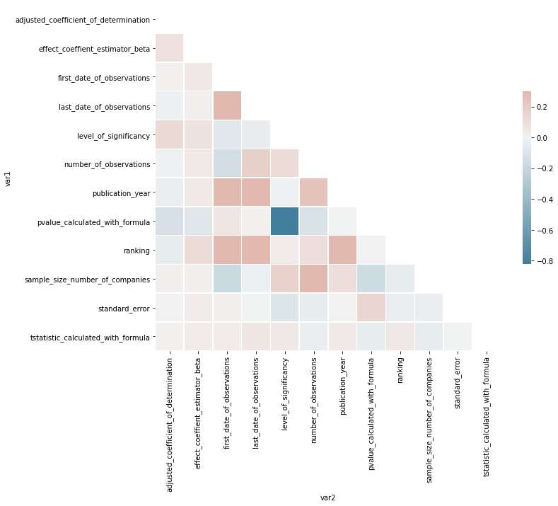

## Scatterplot

From the correlation plot above, pick up a $y$ variables.

Besides, to avoid loading all the table, we have implemented the following rule:

if the size of the table is above >150K rows, then we randomly load 150K rows

First of all, you need to define the Y-axis variables

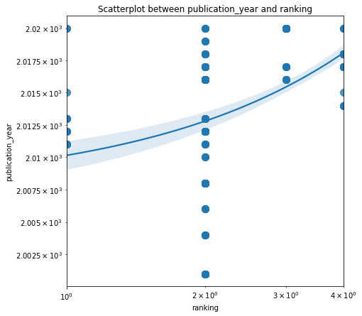

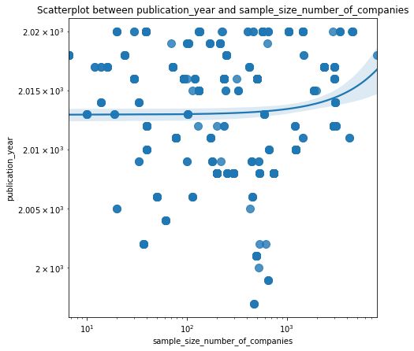

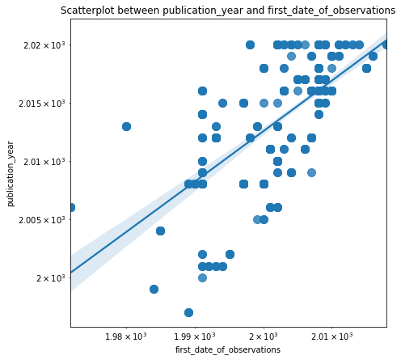

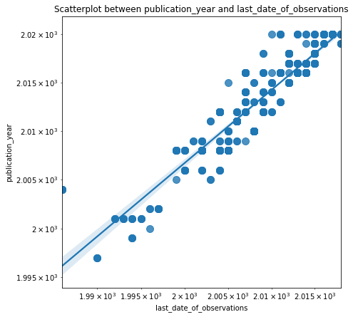

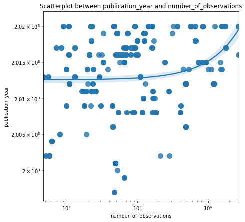

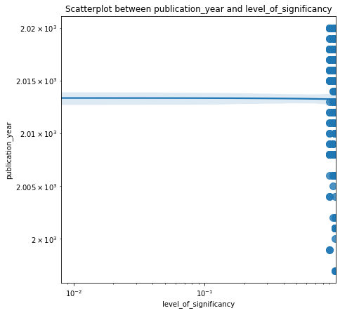

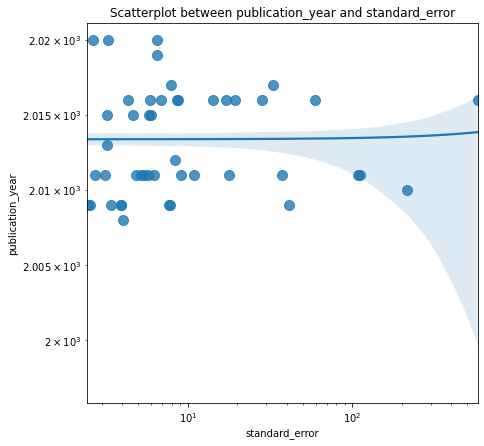

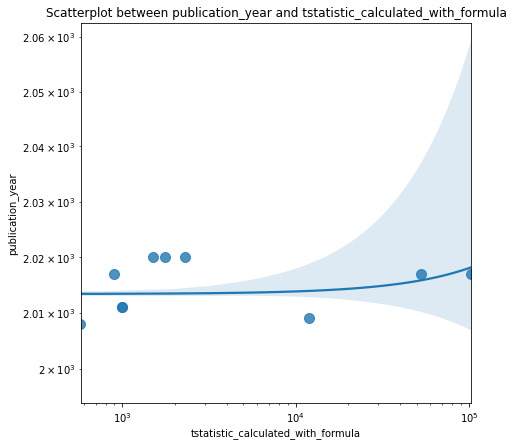

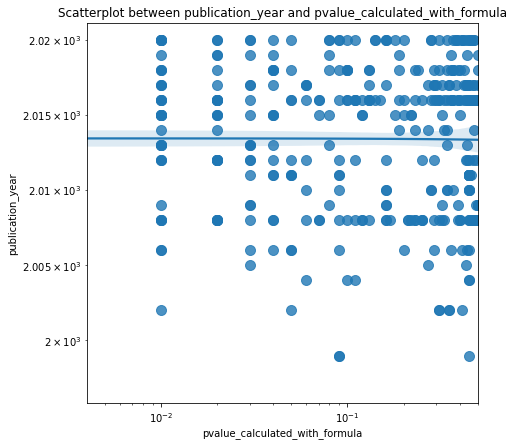

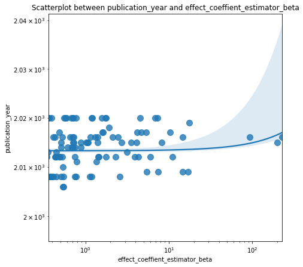

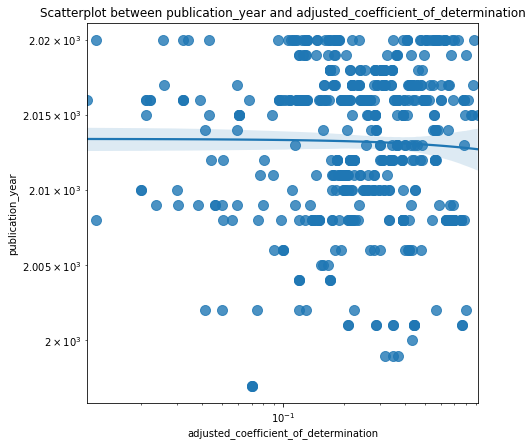

### Diverging bars

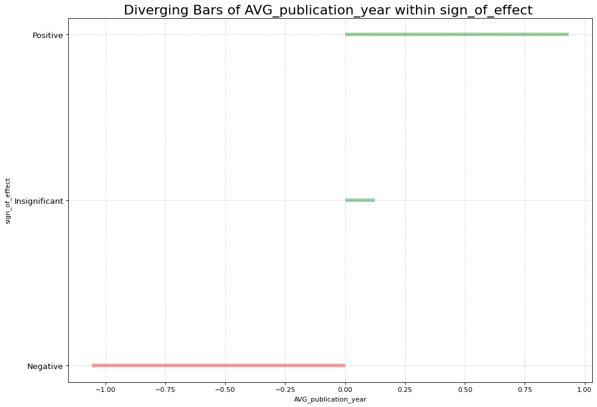

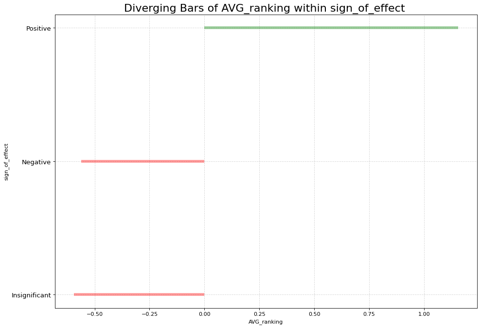

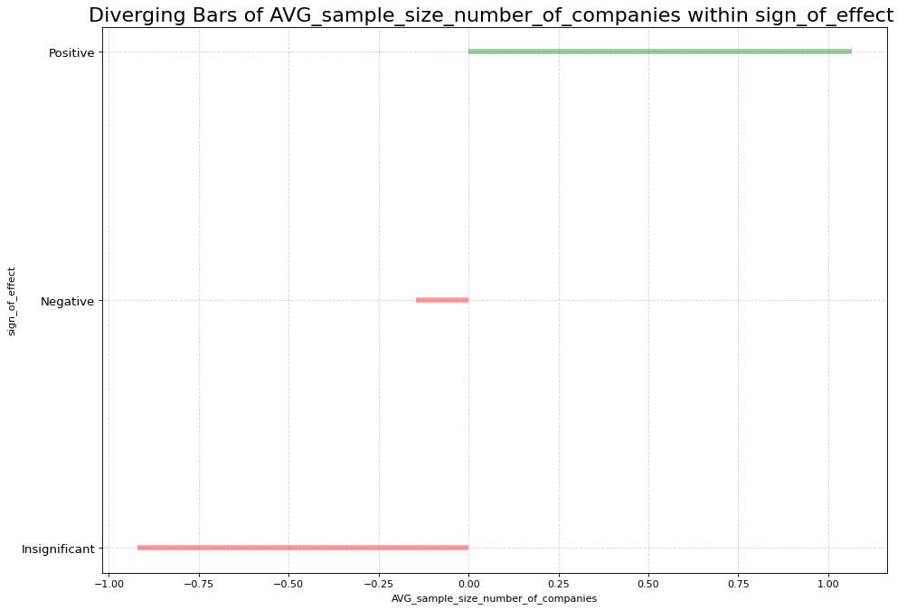

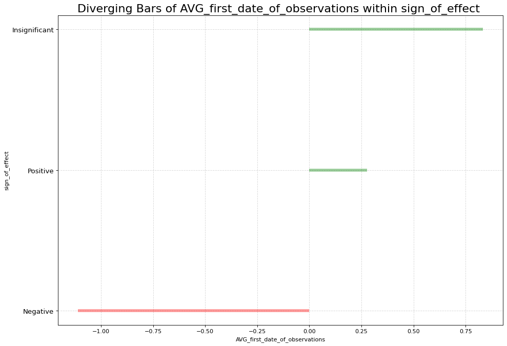

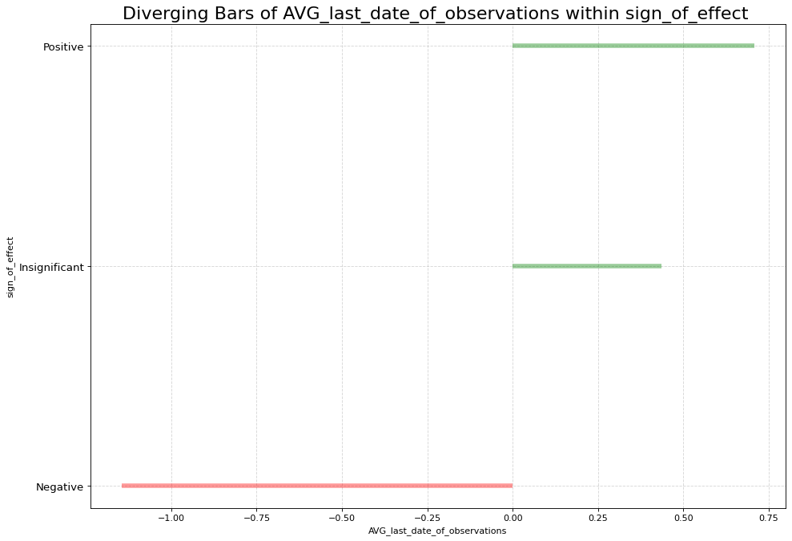

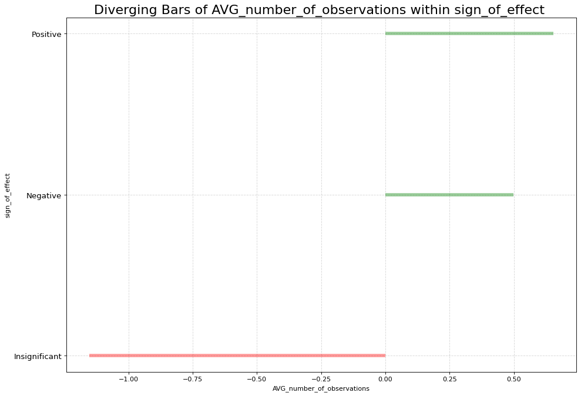

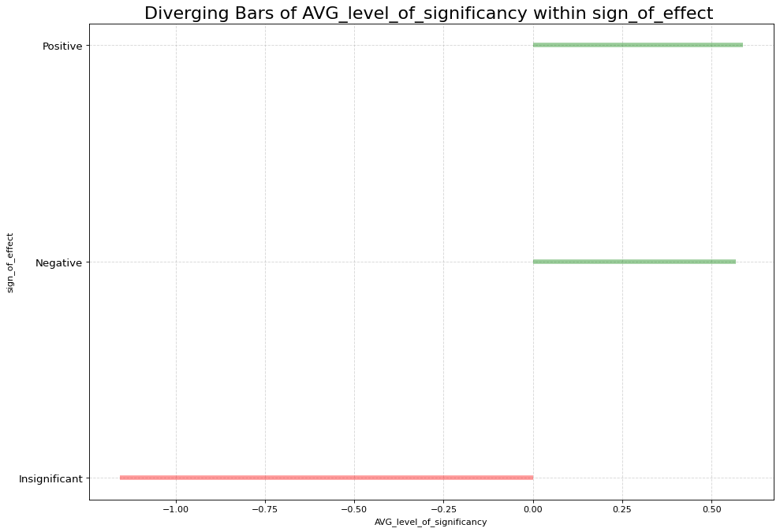

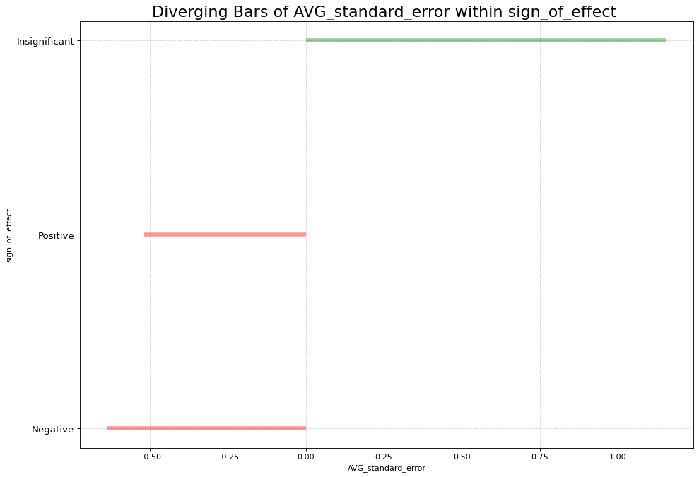

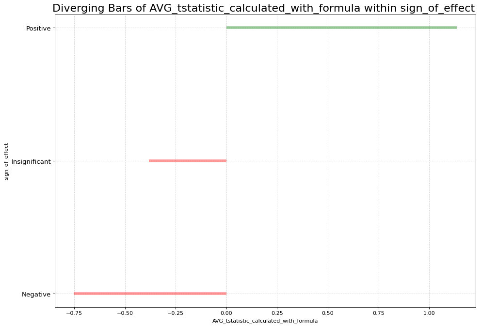

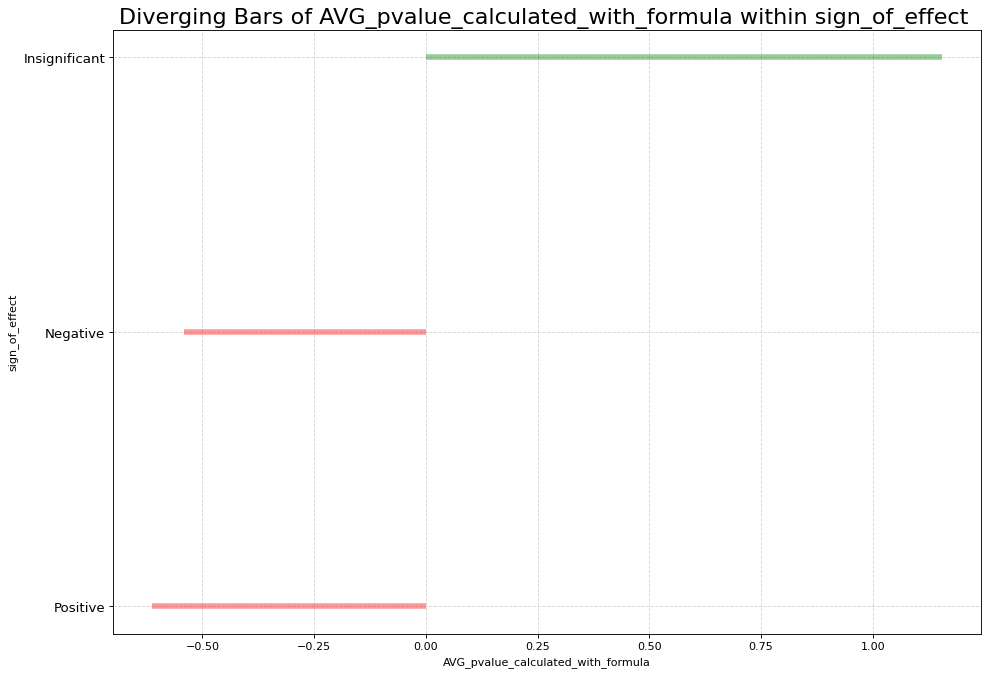

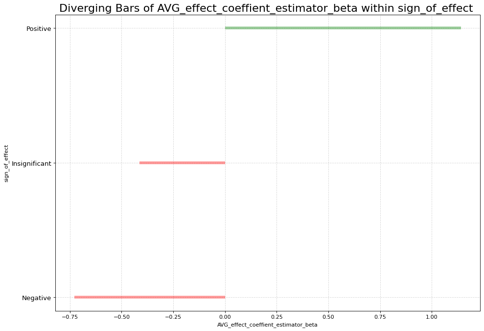

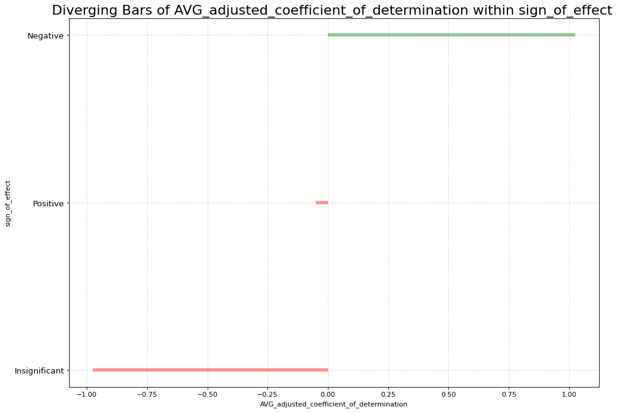